# Third Week: Exploratory Data Analysis

LaLiga Analysis

Milad Aghajohari

2018-02-27 22:04:47

# تمرین سری سوم: از لالیگا تا لیگ برتر

> با استفاده از داده های لیگ دسته اول اسپانیا به سوالات زیر پاسخ دهید. از هر دو ابزار ggplot2 و highcharter برای این کار تصویرسازی استفاده نمایید.

We have some initial codes which will be used throughout the other codes.

```r
warning = FALSE
library(engsoccerdata)
library(dplyr)
```

```r
library(highcharter)
library(ggplot2)
find_champ <- function(games){
  games %>%  select(Season, team = home, op = visitor, s = hgoal, r = vgoal) -> hdata
  games %>%  select(Season, team = visitor, op = home, s = vgoal, r = hgoal) -> vdata
  rbind(hdata, vdata) -> games
  games %>% group_by(Season, team) %>% summarise(score = sum(s>r)*3+sum(s==r), df = sum(s)-sum(r)) %>%
    top_n(1, score) %>% top_n(1, df) %>% slice(1) %>% select(Season, team) -> ret
  return(ret)
}
get_rank_list <- function(games){
  games %>%  select(Season, team = home, op = visitor, s = hgoal, r = vgoal) -> hdata
  games %>%  select(Season, team = visitor, op = home, s = vgoal, r = hgoal) -> vdata
  rbind(hdata, vdata) -> games
  games %>% group_by(Season, team) %>% summarise(score = sum(s>r)*3+sum(s==r), df = sum(s)-sum(r)) %>%
    group_by(Season) %>% arrange(-df) %>% arrange(-score) %>% mutate(rank = 1:n()) -> ret
  ret %>% select(Season, team, rank) -> ret
  return(ret)
}

find_champ_til <- function(games){
  games$Season %>% unique() %>% as.character() -> seas
  games %>% filter(Season == seas) -> games
  low <- 0
  high <- nrow(games)%/%2
  nope <- "nope"
  n.team <- games %>% select(team) %>% unique() %>% nrow()
  while((high - low) > 1){
    i<- (low+high)%/%2
    games %>% filter(nth <= i) -> games.til
    games.til %>% group_by(team) %>%
      summarise(score = sum(s>r)*3+sum(s==r), df = sum(s)-sum(r), rem = 2*(n.team-1) - n()) -> games.til
    games.til %>% mutate(max.pos = score + 3 * rem)->games.til
    games.til %>% arrange(-score) -> games.til
    if(max(games.til[1,"score"])>max(games.til[seq_len(nrow(games.til)-1)+1,"max.pos"])){
      high = i;
    }
    else{
      low = i;
    }
  }
  return(max(games.til[1,"rem"]))
}

find_champ_power <- function(games){
  games$Season %>% unique() %>% as.character() -> seas
  games %>% filter(Season == seas) -> games
  low <- 0
  high <- nrow(games)/2
  nope <- "nope"
  n.team <- games %>% select(team) %>% unique() %>% nrow()
  games -> games.til
  games.til %>% group_by(team) %>%
    summarise(score = sum(s>r)*3+sum(s==r), df = sum(s)-sum(r), rem = 2*(n.team-1) - n()) -> games.til
  games.til %>% mutate(max.pos = score + 3 * rem)->games.til
  games.til %>% arrange(-score) -> games.til
  return(max(games.til[1,"score"])-max(games.til[seq_len(nrow(games.til)-1)+1,"score"]))
}
win_line <- function(games){
  games %>% arrange(Date) ->games
  win_len <- 0
  loss_len <- 0
  equ_len <- 0
  win_s <- 0
  loss_s <- 0
  equ_s <- 0
  games %>% mutate(win = s>r, loss = s<r) -> games
  for (i in seq_len(nrow(games))){
    if(games[[i,"win"]]){
      win_s = win_s + 1
      win_len = max(win_len, win_s)
      equ_s = 0
      loss_s = 0
    }
    else if(games[[i,"loss"]]){
      loss_s = loss_s + 1
      loss_len = max(loss_len, loss_s)
      equ_s = 0
      win_s = 0
    }else{
      equ_s = equ_s + 1
      equ_len = max(equ_len, equ_s)
      win_s = 0
      loss_s = 0
    }
  }
  return(c(win_len, equ_len, loss_len))
}

#will be used in Q7
find_down_til <- function(teamv , sv, rv, nthv){
  games <- data.frame(team = teamv, s = sv, r = rv, nth = nthv)
  low <- 0
  high <- nrow(games)/2
  nope <- "nope"
  n.team <- games %>% select(team) %>% unique() %>% nrow()
  while((high - low) > 1){
    i<- (low+high)%/%2
    games %>% filter(nth <= i) -> games.til
    games.til %>% group_by(team) %>%
      summarise(score = sum(s>r)*3+sum(s==r), df = sum(s)-sum(r), rem = 2*(n.team-1) - n()) -> games.til
    games.til %>% mutate(max.pos = score + 3 * rem)->games.til
    games.til %>% arrange(-score) -> games.til
    if(nrow(games.til)<4 | max(games.til[nrow(games.til),"max.pos"])<max(games.til[nrow(games.til)-3,"score"])){
      high = i;
    }
    else{
      low = i;
    }
  }
  return(c(games.til[nrow(games.til),"rem"],games.til[nrow(games.til),"team"]))
  #return(high)
}

find_down_til_how_soon<-function(teamv , sv, rv, nthv){
  a<-find_down_til(teamv, sv, rv, nthv)[1]
  return(as.integer(a))
}
find_down_til_name<-function(teamv , sv, rv, nthv){
  b<-find_down_til(teamv, sv, rv, nthv)[2]
  return(b)
}

#Global
spain %>% arrange(Date) %>% group_by(Season) %>%  mutate(nth = 1:n()) %>% ungroup()-> spain
spain %>%  select(Season,Date, team = home, op = visitor, s = hgoal, r = vgoal, nth) -> hdata
spain %>%  select(Season,Date, team = visitor, op = home, s = vgoal, r = hgoal, nth) -> vdata
rbind(hdata, vdata) -> games
```

۱. تعداد قهرمانی های تیم ها در تاریخ لالیگا را استخراج کرده و نمودار ستونی آنها را رسم کنید.

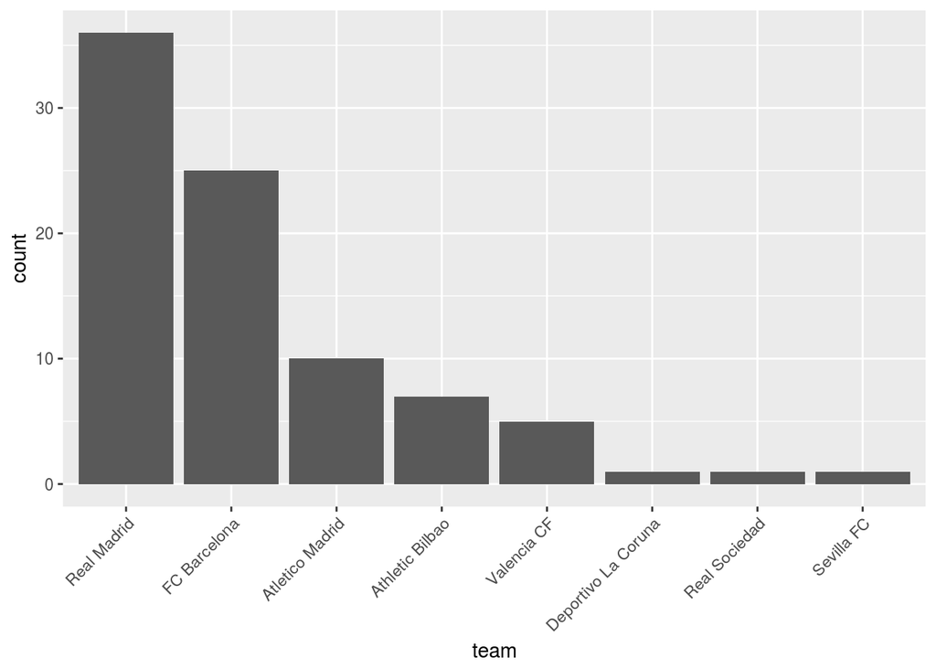

```r
find_champ(spain) -> full_champs
full_champs %>% group_by(team) %>% summarise(count = n()) %>% arrange(-count)->hchart.full.champs
hchart.full.champs$team <- factor(hchart.full.champs$team , levels = hchart.full.champs$team )
ggplot(hchart.full.champs, aes(x = team, y = count))+geom_col()+
  theme(axis.text.x = element_text(angle = 45, hjust = 1))
```

```r
hchart(hchart.full.champs, type = "column", hcaes(x = team, y = count))
```

[interactive chart not shown]

***

۲. کسل کننده ترین لیگ و تیم را بیابید. نمودار ده تیم و ده فصل کسل کننده را رسم کنید.

For teams we have the criterion of
$$\frac{s+r}{n}$$
and the lower the measure,the more boring the team.

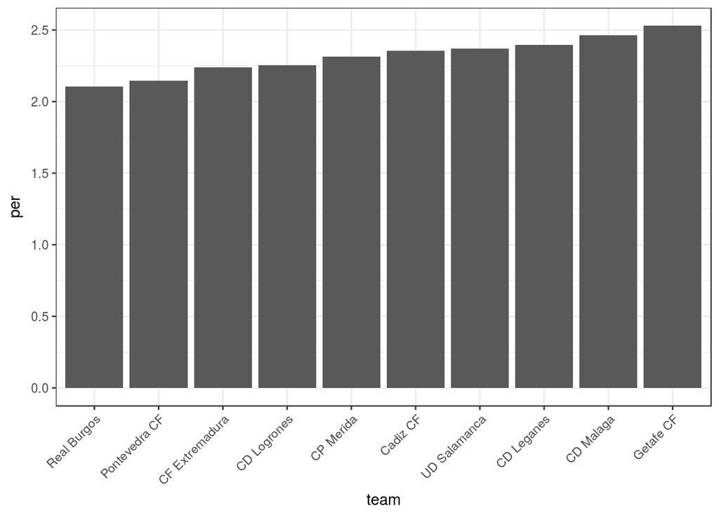

```r
games %>%  group_by(team) %>% summarize(per = sum(s+r)/n()) %>% arrange(per)%>% slice(1:10)->ten.boring.team
ten.boring.team$team <- factor(ten.boring.team$team, levels = ten.boring.team$team)
ggplot(ten.boring.team)+geom_col(aes(x = team, y = per))+theme_bw()+
  theme(axis.text.x = element_text(angle = 45, hjust = 1))
```

```r
hchart(ten.boring.team, type = "column", hcaes(x = team, y = per))
```

[interactive chart not shown]

For teams we have the criterion of
$$\frac{sum(s==r)}{n}$$
and the higher the measure,the more boring the season.

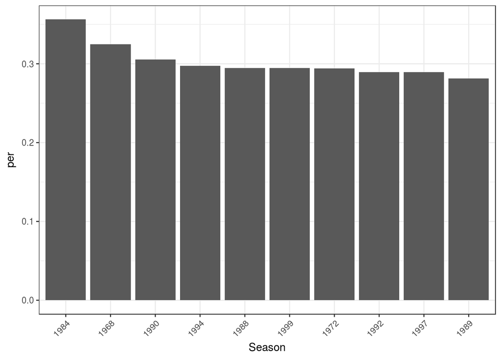

```r
games %>%  group_by(Season) %>% summarize(per = sum(s==r)/n()) %>% arrange(-per)%>% slice(1:10)->ten.boring.season
ten.boring.season$Season <- factor(ten.boring.season$Season, levels = ten.boring.season$Season)
ggplot(ten.boring.season)+geom_col(aes(x = Season, y = per))+theme_bw()+
  theme(axis.text.x = element_text(angle = 45, hjust = 1))
```

```r
hchart(ten.boring.season, type = "column", hcaes(x = Season, y = per))
```

[interactive chart not shown]

***

۳. در چند درصد موارد قهرمان نیم فصل در پایان فصل قهرمان شده است؟

```r
full_champs %>% select(Season, full = team) -> full_champs
spain %>%  group_by(Season) %>% slice(1:(n()%/%2)) %>% find_champ() -> half_champs
half_champs %>% select(Season, half = team) -> half_champs
full_join(half_champs, full_champs,"Season") -> half.vs.full
sum(half.vs.full$full == half.vs.full$half)/nrow(half.vs.full)*100
```

```
## [1] 51.16279
```

۴. در بین سال های ۲۰۰۱ تا ۲۰۱۰ گربه سیاه تیم های بزرگ چه تیم هایی بوده است؟

We have a formual for catness of team B to team A, it is:
$$\frac{average\;rank\;B}{average\;rank\;A}\times (loss\; A+equal\;A)$$

```r
get_rank_list(spain) %>% group_by(team) %>% summarise(ave.rank = mean(rank)) %>% arrange(ave.rank) -> ave_rank

spain %>%  select(Season, team = home, op = visitor, s = hgoal, r = vgoal) -> hdata
spain %>%  select(Season, team = visitor, op = home, s = vgoal, r = hgoal) -> vdata
rbind(hdata, vdata) -> spain.m
spain.m %>% filter(Season >= 2001 & Season <=2009) -> spain.m
spain.m %>% group_by(team, op) %>% summarise(win = sum(s>r), loss = sum(s<r), equ = sum(r==s), n = n())->spain.m
left_join(spain.m, ave_rank, by = c("team" = "team")) %>% full_join(ave_rank, by = c("op" = "team"), suffix = c(".team", ".op"))  -> spain.m.cat
spain.m.cat %>% mutate(cat.black = ave.rank.op/ave.rank.team*(loss+equ)) -> spain.m.cat
spain.m.cat %>% group_by(team) %>% arrange(-cat.black) %>% slice(1:2) -> cat
cat %>%  filter(ave.rank.team < 6)  -> cat
print(cat)
```

```
## # A tibble: 6 x 9
## # Groups:   team [3]
##   team   op      win  loss   equ     n ave.rank.team ave.rank.op cat.black
##   <chr>  <chr> <int> <int> <int> <int>         <dbl>       <dbl>     <dbl>
## 1 Atlet… CA O…     5     9     2    16          5.22       12.0       25.3
## 2 Atlet… RCD …     6     4     6    16          5.22       11.8       22.5
## 3 FC Ba… CA O…     8     3     7    18          2.78       12.0       43.3
## 4 FC Ba… Real…     7     4     5    16          2.78        9.84      31.9
## 5 Real … Depo…     9     8     1    18          2.69        9.91      33.2
## 6 Real … CA O…    11     4     3    18          2.69       12.0       31.3
```

۵. در تاریخ لالیگا کدام تیم رکورددار زودترین قهرمانی است؟ همچنین کدام تیم مقتدرانه ترین قهرمانی را داشته است؟

```r
#########Q5
#A

games %>% group_by(Season) %>% do(data.frame(how.soon = find_champ_til(.))) %>% ungroup() -> til
full_join(til, full_champs) -> til.full
til.full %>% arrange(-how.soon) -> til.full
til.full %>%  slice(1) %>% print()
```

```
## # A tibble: 1 x 3
##   Season how.soon full
##    <dbl>    <dbl> <chr>
## 1   1960     6.00 Real Madrid
```

```r
#B
games %>% group_by(Season) %>% do(data.frame(power = find_champ_power(.))) %>% ungroup -> power
full_join(power, full_champs) -> power
power %>% arrange(-power) %>% slice(1) %>% print()
```

```
## # A tibble: 1 x 3
##   Season power full
##    <dbl> <dbl> <chr>
## 1   1962  21.0 Real Madrid
```

۶. طولانی ترین نوار پیروزی مساوی و شکست مال چه تیم هایی است؟

```r
games %>% group_by(team) %>% arrange(Date) %>% do(data.frame(win.con = win_line(.)[1])) ->games.con1
games %>% group_by(team) %>% arrange(Date) %>% do(data.frame(equ.con = win_line(.)[2])) ->games.con2
games %>% group_by(team) %>% arrange(Date) %>% do(data.frame(loss.con = win_line(.)[3]))->games.con3
games.con1 %>% full_join(games.con2) %>% full_join(games.con3) -> games.con
games.con %>% ungroup() -> games.con
games.con %>% arrange(-win.con) %>% slice(1) %>% select(team, win.con)->E
#print section
paste("the team with most continious wins is", E$team, "with", E$win.con, "continious wins") %>% print()
```

```
## [1] "the team with most continious wins is FC Barcelona with 16 continious wins"
```

```r
games.con %>% arrange(-loss.con) %>% slice(1) %>% select(team, loss.con)->E
paste("The team with most continious losses is",E$team, "with", E$loss.con, "continious losses.")
```

```
## [1] "The team with most continious losses is UD Las Palmas with 11 continious losses."
```

```r
games.con %>% arrange(-equ.con) %>% slice(1) %>% select(team, equ.con)->E
paste("The team with most continious equals is",  E$team, "with", E$equ.con, "continious equals.")
```

```
## [1] "The team with most continious equals is Burgos CF with 9 continious equals."
```

۷. زودترین سقوط مال کدام تیم بوده است؟

```r
games %>% group_by(Season) %>% do(.,data.frame(how.soon =  find_down_til_how_soon(.$team, .$s, .$r, .$nth)))-> til1
games %>% group_by(Season) %>% do(.,data.frame(soon.name =  find_down_til_name(.$team, .$s, .$r, .$nth)))-> til2
```

[output not shown]

[output cut: 199 more lines]

[output not shown]

```r
full_join(til1, til2)->til
til %>% arrange(-how.soon) -> til
til %>% ungroup()%>%  slice(1) %>%print()
```

```
## # A tibble: 1 x 3
##   Season how.soon team
##    <dbl>    <int> <chr>
## 1   1997        8 Sporting Gijon
```

```r
games %>% mutate(score = (s>r)*3+(s==r)*1, df = s - r ) %>% group_by(Season, team) %>%
  mutate(week.num = row_number(Date)) %>% arrange(week.num) %>% mutate(score = cumsum(score), df = cumsum(df)) %>%
  ungroup() %>% group_by(Season, week.num) %>% mutate(rank.week = n()+1-row_number(score*10000+df)) -> games.rank
games.rank %>% filter(Season == 1998) %>%
  hchart(type = "line", hcaes(x = week.num, y = rank.week, group = team)) %>%
  hc_yAxis(reversed = TRUE)
```

[interactive chart not shown]